# 3 Shallow Water Systems

## 3.1 Overview

The shallow water equations are a model of a thin layer of fluid with constant density which is bounded by a rigid surface from below and by a free surface from above. By ``thinness” – which is the most defining feature of these fluids – we mean the horizontal length scales of these flows are much larger than their vertical scales (and hence the name shallow!). Other characteristics of these equations which we will discuss in this section are the direct consequence of the thinness and constant density assumptions.

The shallow water equations are one of the simplest sets of PDEs describing geophysical fluids, yet they are very useful. They are used in practical models of shallow lakes, rivers and coastal flows. Due to their relative simplicity, many theoretical concepts in geophysical fluid dynamics are first investigated for shallow water systems before being studied in more complex systems. They also incorporate many phenomena that characterise atmospheric and oceanic flows such as geostrophic balance and waves (we will discuss these later in the course). The practical importance of shallow water equations aside, their derivation is a good example of using rigorous mathematical steps and physical assumptions to reduce the Boussinsq equations to a much simpler set.

## 3.2 Derivation

We use the defining characteristics of shallow water flows to derive their governing equations. Before that, let’s clarify the notation and conventions we are going to use (this is sometimes the most confusing part about shallow water systems because different sources in the literature adopt very different notation). We assume the $z$ axis is perpendicular to the layer of water as shown in Figure 3.1. $z=0$ can be placed at any arbitrary level (naturally we want to see it close the bottom surface). $\eta(x,y,t)$ is the vertical position of fluid surface measured from $z=0$. Likewise, $\eta_b(x,y,t)$ is the vertical height of bottom topography measured from $z=0$. $h(x,y,t)$ is the thickness of water column measured from bottom boundary all the way to free surface, i.e. $h = \eta - \eta_b$. The thinness of fluid has an important consequence: the vertical velocity (in the $z$ direction) is much smaller than the horizontal velocity components (but is not necessarily zero). Hence, we only consider the two-dimensional horizontal velocity denoted by $\vb =(u,v)$ and assume $w \ll u, v$. Lastly, we denote the horizontal gradient operator by $\gradH = (\partial / \partial x, \partial / \partial y)$.

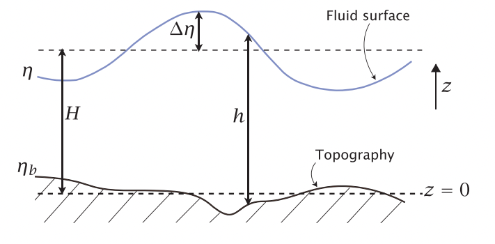

Figure 3.1: A shallow water system. $h$ is the thickness of a water column, $H$ is the mean thickness, $\eta$ is the height of the free surface and $\eta_b$ is the height of the lower rigid. $\Delta \eta$ is the deviation of free from average height.

### 3.2.1 Momentum equations

One of the main consequences of small vertical velocity appears in the vertical momentum equation. Let’s consider the vertical momentum equation in the Boussinesq system (i.e., Equation 2.6)
$$\frac{\partial w}{\partial t} + (\vb \cdot\gradH)w + w \frac{\partial w}{\partial z} = -\frac{1}{\bar\rho} \frac{\partial p}{\partial z} -\frac{\rho}{\bar\rho}g.
\tag{3.1}$$
Assuming $w$ to be smaller than the other variables, the vertical momentum equation then reduces to
$$\frac{\partial p}{\partial z} = - \rho g,$$
which is simply the hydrostatic balance that was discussed in Section 1.3 (cf. Equation 1.9). Because the density is assumed constant ($\rho = \rho_0$), we may integrate this equation from $\eta$ to an arbitrary height $z$ to give
$$p(x,y,z,t) - p(x,y,\eta(x,y,t),t) = \rho_0 g (\eta(x,y,t) - z).
\tag{3.2}$$
It is physically justified to assume the pressure at the free surface $p(x,y,\eta,t)$ is constant (for some applications we may need to change this assumption though). Hence, we can take the horizontal gradient of both sides of Equation 3.2 to arrive at
$$\gradH \ p = \rho_0 g \ \gradH \ \eta.
\tag{3.3}$$
Now we consider the horizontal momentum equation in Equation 2.6 and substitute for the horizontal pressure gradient using Equation 3.3
$$\frac{\partial \vb}{\partial t} + (\vb \cdot\gradH) \vb = - g \ \gradH \ \eta,
\tag{3.4}$$
where we also neglected the vertical velocity at leading order. Note that the right-hand side of this equation is independent of $z$. Hence, if we assume the velocity is initially independent of $z$, it should remain independent of $z$, i.e. $\vb = \vb(x,y,t)$. As a consequence, for the rest of this chapter we do not deal with $z$ derivative. We also simplify the notation by replacing $\gradH$ with $\grad$ in the context of shallow water equation since there is no $z$ dependence. For example, we write Equation 3.5 as
$$\frac{D \vb}{D t} = - g \ \grad \eta.
\tag{3.5}$$

Note that for three-dimensional flows such as those described by the Boussinesq equations, we still distinguish between horizontal and three-dimensional gradient and show them with $\gradH$ and $\grad$, respectively.

### 3.2.2 Mass continuity equation

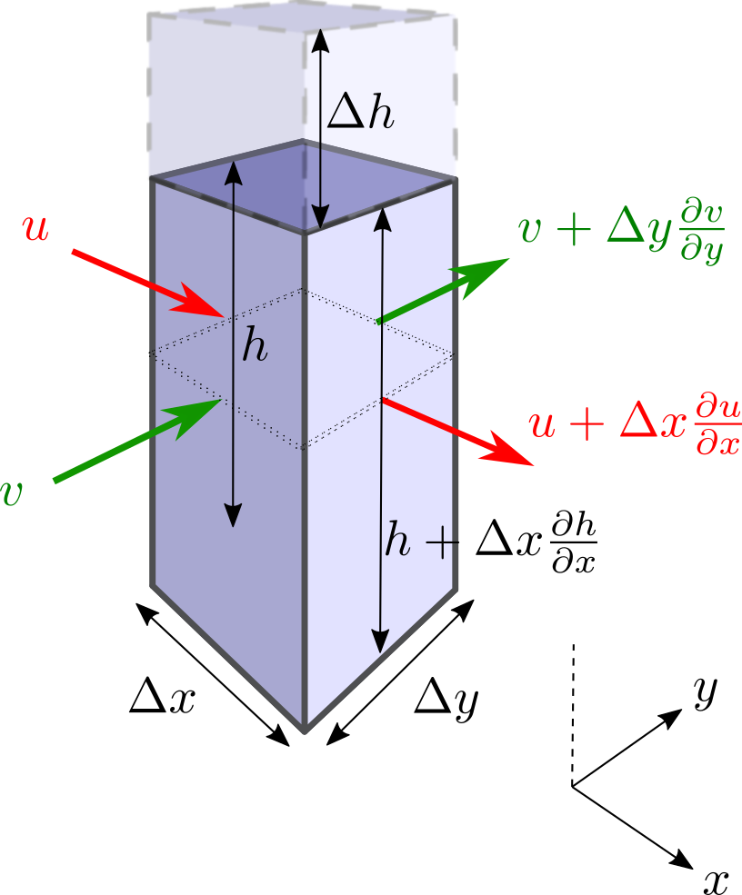

Figure 3.2: A column of fluid in shallow water.

Consider a (Cartesian) column of shallow water as shown in Figure 3.2. The height of this column $h$ is measured from the bottom boundary to the free surface. The cross-sectional area of this column is $\Dl x \Dl y$. If the fluid enters this column from the sides, its height has to increase to conserve mass (note that the density is constant and the fluid is incompressible). More quantitatively, let’s consider the two sides perpendicular to the $x$-axis. If the velocity normal to one of the sides is $u$, the normal velocity to the other side will be $u + \Dl x \ {\partial u} / {\partial x}$ (see Figure 3.2). Likewise, If the thickness of one side is $h$, the thickness of the other side will be $h + \Dl x \ {\partial h} / {\partial x}$. The mass flux through a side is calculated as the normal velocity times the surface area of the side times density. For example, if the normal velocity and vertical thickness are $u$ and $h$ respectively, the mass flux will be $\rho_0 u h \Dl y$ (without loss of generality we assume the velocity $u$ is pointing inward). Hence, the total amount of mass entering/leaving from these two sides is

$$\begin{align*}
\text{MF}_x = \text{mass flux along} &\text{ the $x$ axis} = \rho_0 u h \Dl y - \rho_0 \left( u + \Dl x \ \frac{\partial u}{\partial x} \right) \left(h + \Dl x \ \frac{\partial h}{\partial x} \right) \Dl y \\
&= -\rho_0 \Dl x \ \frac{\partial u}{\partial x} h \Dl y
-\rho_0 u \ \Dl x \ \frac{\partial h}{\partial x} \Dl y
-\rho_0 \Dl x \ \frac{\partial u}{\partial x} \Dl x \ \frac{\partial h}{\partial x} \Dl y
\end{align*}$$
Likewise, we obtain the total mass flux along the $y$ axis
$$\text{MF}_y
= -\rho_0 \Dl y \ \frac{\partial v}{\partial y} h \Dl x
-\rho_0 v \ \Dl y \ \frac{\partial h}{\partial y} \Dl x
-\rho_0 \Dl y \ \frac{\partial v}{\partial y} \Dl y \ \frac{\partial h}{\partial y} \Dl x$$
The rate of change of mass in this fluid column is $\rho_0 \Dl x \Dl y \Dl h / \Dl t$ which should be equal to mass flux from the sides, i.e.,
$$\rho_0 \Dl x \Dl y \frac{\Dl h }{\Dl t } = \text{MF}_x + \text{MF}_y.$$
After dividing this equation by $\rho_0 \Dl x \Dl y$ and taking the limit as $\Dl x, \Dl y, \Dl t \to 0$, we find
$$\frac{\partial h}{\partial t} = - h \left( \frac{\partial u}{\partial x} +\frac{\partial v}{\partial y} \right) - u \frac{\partial h}{\partial x} - v \frac{\partial h}{\partial y}$$
which can be written as
$$\frac{\partial h}{\partial t} + \gradH \cdot (h \vb)=0, \quad \text{or} \quad \frac{D h}{D t} + h \gradH \cdot \vb=0.
\tag{3.6}$$
Note that unlike Boussinesq or incompressible flows, the shallow water velocity is not divergence free. This is because the columns of fluids can be compressed by increasing their height.

The conservation of mass equation for the shallow water system can be derived from 3D mass conservation equation using $w \ll u, v$ (see the assignments).

In summary, in a non-rotating frame, the inviscid shallow water equations are

**Inviscid Shallow Water Equations**

$$\text{momentum:} \quad \frac{D \vb}{D t} = - g \ \gradH \eta. \tag{3.7}$$
$$\text{mass continuity:} \quad \frac{\partial h}{\partial t} + \gradH \cdot (h \vb) = 0, \quad \text{or} \quad \frac{D h}{D t} + h \gradH \cdot \vb=0 \tag{3.8}$$
$$\text{height relation:} \quad h(x,y,t) = \eta(x,y,t) - \eta_b(x,y,t). \tag{3.9}$$

**Example**

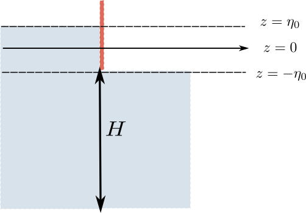

Figure 3.3: A schematic figure of dam break with two levels of water on each side.

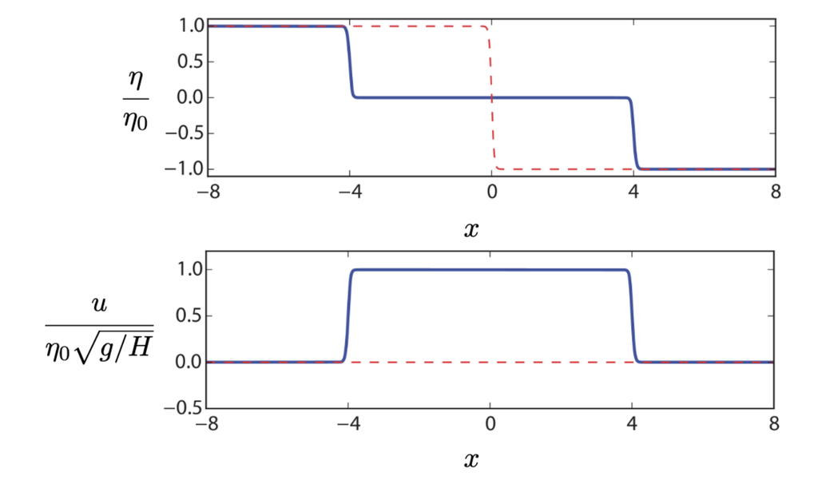

Figure 3.4: The height (top) and velocity (bottom) for the propagating height disturbance in shallow water system. The variables are normalised. The dashed line shows the initial condition and the solid line the solution at $t=4/c$.

## 3.3 Vortices on sloping beaches

There are cases where the changes in $\eta$ are small compared to the flow and bottom surface, but the surface pressure is no longer constant. In such cases, we need to modify the shallow water equations by changing the top boundary condition from constant pressure to constant $\eta$. This boundary condition is known as a *rigid lid* as it is literally the equivalent of putting a rigid lid on the top. Using this condition, Equation 3.2 changes to
$$p(x,y,z,t) - p(x,y,0,t) = \rho_0 g (0 - z),$$
where we place our $z$ axis at the top surface that is nearly constant. Taking the horizontal gradient of this equation gives,
$$\gradH \ p(x,y,z,t) = \gradH \ (p_0(x,y,t) =p(x,y,0,t)),$$
where we used $p_0$ to denote the surface pressure. Note the constant $\eta$ assumption means that $h(x,y,t) = - \eta_b(x,y)$. As a result, if the bottom surface doesn’t change with time (reasonable assumption for many problems with a solid boundary), $\partial h /\partial t =0$. Using these assumptions, we can write the rigid-lid shallow water equations as
$$\frac{D \vb}{D t} = - \frac{1}{\rho_0}\ \gradH p_0, \tag{3.14}$$
$$\gradH \cdot (h \vb) = 0, \tag{3.15}$$
$$h(x,y,t) = \eta_b(x,y,t). \tag{3.16}$$

The rigid-lid shallow water system is a good approximation for flows on sloping beaches as surface variations compared to the changes of the bottom slope and velocities are negligible. This is also a good model for lab experiments where the flow is confined by a solid wall from the top.

We can transform equations (3.14)-(3.16) into the following equation (see the assignment for derivation)
$$q = \frac{\nabla \times \vb}{h} = \frac{\partial v/\partial x - \partial u/\partial y}{h}, \quad \frac{D q}{D t} = 0. \tag{3.17}$$

$q$ as defined in Equation 3.17 is a special case of a quantity known as Potential Vorticity (PV). We will introduce the general form of this quantity in chapter 5 and show that is it conserved for some limits of the shallow water and Boussinesq equations. Such a conservation law is an important element of large-scale atmospheric and oceanic flows.